# Prediction of Returned Shelter Dogs

Spring 2025 Data Science Project

Team:

- Emily Chen
- David Guan
- Suhan Neema
- Bhargav Srinivasan
- Danhong Wei
- Anya Zhang

Contribution

**A: Project Idea**

The group proposed a couple of ideas along with datasets and we voted on which project to go with.

Anya: I summarized the concept of our project in the introduction, emphasizing the significance of predicting returns for shelters and the wellbeing of animals. Additionally, I briefly explained why we chose decision tree based models for our chosen data.

**B: Dataset Curation and Preprocessing**

David: I imported the data and cleaned it by unnecessary columns and null entries. I also converted dates and times from strings into the more usable type DateTime

Suhan and Danhong: I worked with Danhong to preprocess the data related to dog breeds. We did a bit of feature engineering, grouping together the entries by ID, to understand the history of adoptions for each dog. We created a new column to reflect whether a dog was returned at least one time.

Emily: I examined the impact of intake reasons on shelter duration for dogs. I worked on calculating the time spent in the shelter, verifying normality through KDE plots, and applying the Kruskal-Wallis test followed by Dunn's post-hoc test with Bonferroni correction to identify statistically significant differences across intake reason groups.

**C: Data Exploration and Summary Statistics**

Suhan and Danhong: Since we divided up the preprocessing work, I worked with Danhong to explore the data related to the dog breed. We first created a contingency table for the number of dogs returned by breed. We conducted a chi-square test and rejected the null hypothesis, concluding that a dog’s breed does affect whether it is returned.

Danhong: I fixed one of the graph to show the relationship between dog breeds and dogs being returned as now it shows the top 10 breeds who have the highest rate of being returned.

**D: ML Algorithm Design/Development**

**E: ML Algorithm Training and Test Data Analysis**

**F: Visualization, Result Analysis, Conclusion**

Anya: Analyzed our project wholistically to see what steps should be clarified for the understanding of an uninformed reader and what additional information we can add to further the insights of an informed reader. Summarized these elements in the conclusion.

Suhan: I created an additional visualization to show the aggregated influence of breed and color on return status of dogs.

**F: Final Tutorial Report Creation**

David: Made the .ipynb notebook into a github page

# **Introduction**

By doing this project, it could help shelters make more informed adoption recommendations and improve long-term placement outcomes. Identifying the traits that lead to unsuccessful adoptions can help shelters proactively work on addressing behavioral issues and match dogs to more suitable homes. Overall, this can help reduce stress in the animals involved as well as reduce euthanasia rates in shelters.

The data set will we will use is from [Bloomington Animal Shelter](https://www.kaggle.com/datasets/thedevastator/analyzing-adoption-trends-at-the-bloomington-ani) based in Indiana. We will apply decision tree algorithms due to their ability to handle categorical features like breed.

# **Data Preprocessing and cleaning (Data Curation)**

```python
from google.colab import drive
import scipy.stats as stats
import pandas as pd
drive.mount('/content/drive')
```

This dataset contains detailed information about the outcomes of animals adopted from the Bloomington Animal Shelter

The table is originally sorted by "id" which is unique for each specific animal

The columns include:  
**intakedate**: Date of admission to the shelter. (Date)  
**intakereason**: Reason for admission to the shelter. (String)  
**istransfer**: Whether the animal was transferred from another shelter. (Boolean)  
**sheltercode**: Unique code assigned to the animal. (String)  
**animalname**: Name of the animal. (String)  
**breedname**: Breed of the animal. (String)  
**basecolour**: Color of the animal. (String)  
**speciesname**: Species of the animal. (String)  
**animalage**: Age of the animal. (Integer)  
**sexname**: Sex of the animal. (String)  
**location**: Location of the animal. (String)  
**movementdate**: Date of movement. (Date)  
**movementtype**: Type of movement. (String)  
**istrial**: Whether the animal was on trial. (Boolean)  
**returndate**: Date of return. (Date)  
**returnedreason**: Reason for return. (String)  
**deceaseddate**: Date of death. (Date)  
**deceasedreason**: Reason for death. (String)  
**diedoffshelter**: Whether the animal died offsite. (Boolean)  
**puttosleep**: Whether the animal was euthanized. (Boolean)

```python
df = pd.read_csv('animal-data-1.csv')

df
```

|  | index | id | intakedate | intakereason | istransfer | sheltercode | identichipnumber | animalname | breedname | basecolour | ... | movementdate | movementtype | istrial | returndate | returnedreason | deceaseddate | deceasedreason | diedoffshelter | puttosleep | isdoa |
| --- | --- | --- | --- | --- | --- | --- | --- | --- | --- | --- | --- | --- | --- | --- | --- | --- | --- | --- | --- | --- | --- |
| 0 | 0 | 15801 | 2009-11-28 00:00:00 | Moving | 0 | C09115463 | 0A115D7358 | Jadzia | Domestic Short Hair | Tortie | ... | 2017-05-13 00:00:00 | Adoption | 0.0 | NaN | Stray | NaN | Died in care | 0 | 0 | 0 |
| 1 | 1 | 15932 | 2009-12-08 00:00:00 | Moving | 0 | D09125594 | 0A11675477 | Gonzo | German Shepherd Dog/Mix | Tan | ... | 2017-04-24 00:00:00 | Adoption | 0.0 | NaN | Stray | NaN | Died in care | 0 | 0 | 0 |
| 2 | 2 | 28859 | 2012-08-10 00:00:00 | Abandoned | 0 | D12082309 | 0A13253C7B | Maggie | Shep Mix/Siberian Husky | Various | ... | 2017-04-15 00:00:00 | Adoption | 0.0 | NaN | Stray | NaN | Died in care | 0 | 0 | 0 |
| 3 | 3 | 30812 | 2013-01-11 00:00:00 | Abandoned | 0 | C1301091 | 0A13403D4D | Pretty Girl | Domestic Short Hair | Dilute tortoiseshell | ... | 2017-04-18 00:00:00 | Foster | 0.0 | 2018-05-29 00:00:00 | Stray | NaN | Died in care | 0 | 0 | 0 |
| 4 | 4 | 30812 | 2013-01-11 00:00:00 | Abandoned | 0 | C1301091 | 0A13403D4D | Pretty Girl | Domestic Short Hair | Dilute tortoiseshell | ... | 2018-05-29 00:00:00 | Adoption | 0.0 | NaN | Stray | NaN | Died in care | 0 | 0 | 0 |
| ... | ... | ... | ... | ... | ... | ... | ... | ... | ... | ... | ... | ... | ... | ... | ... | ... | ... | ... | ... | ... | ... |
| 10285 | 10285 | 64584 | 2019-08-27 16:52:09 | Litter relinquishment | 0 | C19081429 | 981020029330984 | Max | Domestic Medium Hair | Orange and White | ... | 2019-08-29 00:00:00 | Adoption | 0.0 | NaN | Stray | NaN | Court Order/ Legal | 0 | 0 | 0 |
| 10286 | 10286 | 64588 | 2019-08-27 18:14:11 | Stray | 0 | C19081418 | 981020033133599 | Punkin | Domestic Short Hair | Calico | ... | 2019-08-28 00:00:00 | Foster | 0.0 | NaN | Stray | NaN | Court Order/ Legal | 0 | 0 | 0 |
| 10287 | 10287 | 64606 | 2019-08-29 12:10:21 | Stray | 0 | D19081440 | 0A1243400C | Dozer | Coonhound | Red | ... | 2019-08-29 00:00:00 | Reclaimed | 0.0 | NaN | Stray | NaN | Court Order/ Legal | 0 | 0 | 0 |
| 10288 | 10288 | 64608 | 2019-08-29 18:58:06 | Stray | 0 | D19081421 | 982000363034690 | Lucy Farmer | Beagle | Tricolour | ... | 2019-08-30 00:00:00 | Reclaimed | 0.0 | NaN | Stray | NaN | Court Order/ Legal | 0 | 0 | 0 |
| 10289 | 10289 | 64609 | 2019-08-30 10:22:37 | Stray | 0 | D19081442 | NaN | Rocky Hartfield | Labrador Retriever | Brown | ... | 2019-08-30 00:00:00 | Reclaimed | 0.0 | NaN | Stray | NaN | Court Order/ Legal | 0 | 0 | 0 |

10290 rows × 24 columns

Some columns that are not necessary include:

**sheltercode** and **identichipnumber**: can use id instead

**location**: locations like "cat room b" or "stray dogs alpha" are names specific to the shelther and are hard to interpret

So we will delete these

```python
del df['sheltercode']
del df['identichipnumber']
del df['location']

#index also seems redundant
del df['index']
```

Notice how some "**id**" appear multiple times, so lets make a graph to get an idea of how many times the animals are getting adopted

We'll make a new column **numintakes** that tracks the number of occurences found with the same id

```
id
58510    11
60702    11
55456    10
61384    10
58410     7
         ..
64519     1
64518     1
64516     1
47239     1
46693     1
Name: count, Length: 7288, dtype: int64
```

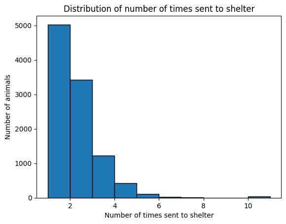

```python
id_counts = df['id'].value_counts() #gives a series of each id and the amount of occurences
print(id_counts)

# for example: id 58510 roxy the dog has gotten checked into the shelter 11 times!
df['numintakes'] = df['id'].map(id_counts) #map matches the id to it's count in id_counts
df



import matplotlib.pyplot as plt

# Create a histogram of the numintakes column
plt.hist(df['numintakes'], edgecolor = 'black')
plt.xlabel('Number of times sent to shelter')
plt.ylabel('Number of animals')
plt.title('Distribution of number of times sent to shelter')
plt.show()
```

**Cleaning the data**

First lets check for Null values.

```python
for col in df.columns:
    print(col, df[col].isna().sum())
```

```
id 0
intakedate 0
intakereason 2
istransfer 0
animalname 0
breedname 45
basecolour 0
speciesname 0
animalage 0
sexname 0
movementdate 0
movementtype 0
istrial 1
returndate 7034
returnedreason 0
deceaseddate 9964
deceasedreason 0
diedoffshelter 0
puttosleep 0
isdoa 0
numintakes 0
```

Lets remove any row that has intakereason, breedname, or istrial null.

```python
df = df[df['intakereason'].isna() == False]
df = df[df['breedname'].isna() == False]
df = df[df['istrial'].isna() == False]

for col in df.columns:
    print(col, df[col].isna().sum())
```

```
id 0
intakedate 0
intakereason 0
istransfer 0
animalname 0
breedname 0
basecolour 0
speciesname 0
animalage 0
sexname 0
movementdate 0
movementtype 0
istrial 0
returndate 6990
returnedreason 0
deceaseddate 9917
deceasedreason 0
diedoffshelter 0
puttosleep 0
isdoa 0
numintakes 0
```

The dates are currently stored as strings so I'll convert them to the DateTime type to make them easier to work with.

```python
print(df.dtypes)
df['intakedate'] = pd.to_datetime(df['intakedate'])
df['movementdate'] = pd.to_datetime(df['movementdate'])
df['returndate'] = pd.to_datetime(df['returndate'])
df['deceaseddate'] = pd.to_datetime(df['deceaseddate'])
df.dtypes
```

```
id                  int64
intakedate         object
intakereason       object
istransfer          int64
animalname         object
breedname          object
basecolour         object
speciesname        object
animalage          object
sexname            object
movementdate       object
movementtype       object
istrial           float64
returndate         object
returnedreason     object
deceaseddate       object
deceasedreason     object
diedoffshelter      int64
puttosleep          int64
isdoa               int64
numintakes          int64
dtype: object
```

|  | 0 |
| --- | --- |
| id | int64 |
| intakedate | datetime64[ns] |
| intakereason | object |
| istransfer | int64 |
| animalname | object |
| breedname | object |
| basecolour | object |
| speciesname | object |
| animalage | object |
| sexname | object |
| movementdate | datetime64[ns] |
| movementtype | object |
| istrial | float64 |
| returndate | datetime64[ns] |
| returnedreason | object |
| deceaseddate | datetime64[ns] |
| deceasedreason | object |
| diedoffshelter | int64 |
| puttosleep | int64 |
| isdoa | int64 |
| numintakes | int64 |

**dtype:** object

```python
#result after preprocessing and cleaning data

df
```

|  | id | intakedate | intakereason | istransfer | animalname | breedname | basecolour | speciesname | animalage | sexname | ... | movementtype | istrial | returndate | returnedreason | deceaseddate | deceasedreason | diedoffshelter | puttosleep | isdoa | numintakes |
| --- | --- | --- | --- | --- | --- | --- | --- | --- | --- | --- | --- | --- | --- | --- | --- | --- | --- | --- | --- | --- | --- |
| 0 | 15801 | 2009-11-28 00:00:00 | Moving | 0 | Jadzia | Domestic Short Hair | Tortie | Cat | 9 years 2 months. | Female | ... | Adoption | 0.0 | NaT | Stray | NaT | Died in care | 0 | 0 | 0 | 1 |
| 1 | 15932 | 2009-12-08 00:00:00 | Moving | 0 | Gonzo | German Shepherd Dog/Mix | Tan | Dog | 9 years 1 month. | Male | ... | Adoption | 0.0 | NaT | Stray | NaT | Died in care | 0 | 0 | 0 | 1 |
| 2 | 28859 | 2012-08-10 00:00:00 | Abandoned | 0 | Maggie | Shep Mix/Siberian Husky | Various | Dog | 6 years 8 months. | Female | ... | Adoption | 0.0 | NaT | Stray | NaT | Died in care | 0 | 0 | 0 | 1 |
| 3 | 30812 | 2013-01-11 00:00:00 | Abandoned | 0 | Pretty Girl | Domestic Short Hair | Dilute tortoiseshell | Cat | 8 years 11 months. | Female | ... | Foster | 0.0 | 2018-05-29 | Stray | NaT | Died in care | 0 | 0 | 0 | 2 |
| 4 | 30812 | 2013-01-11 00:00:00 | Abandoned | 0 | Pretty Girl | Domestic Short Hair | Dilute tortoiseshell | Cat | 8 years 11 months. | Female | ... | Adoption | 0.0 | NaT | Stray | NaT | Died in care | 0 | 0 | 0 | 2 |
| ... | ... | ... | ... | ... | ... | ... | ... | ... | ... | ... | ... | ... | ... | ... | ... | ... | ... | ... | ... | ... | ... |
| 10285 | 64584 | 2019-08-27 16:52:09 | Litter relinquishment | 0 | Max | Domestic Medium Hair | Orange and White | Cat | 21 weeks. | Male | ... | Adoption | 0.0 | NaT | Stray | NaT | Court Order/ Legal | 0 | 0 | 0 | 1 |
| 10286 | 64588 | 2019-08-27 18:14:11 | Stray | 0 | Punkin | Domestic Short Hair | Calico | Cat | 6 weeks. | Female | ... | Foster | 0.0 | NaT | Stray | NaT | Court Order/ Legal | 0 | 0 | 0 | 1 |
| 10287 | 64606 | 2019-08-29 12:10:21 | Stray | 0 | Dozer | Coonhound | Red | Dog | 6 years 8 months. | Male | ... | Reclaimed | 0.0 | NaT | Stray | NaT | Court Order/ Legal | 0 | 0 | 0 | 1 |
| 10288 | 64608 | 2019-08-29 18:58:06 | Stray | 0 | Lucy Farmer | Beagle | Tricolour | Dog | 7 years 5 months. | Female | ... | Reclaimed | 0.0 | NaT | Stray | NaT | Court Order/ Legal | 0 | 0 | 0 | 1 |
| 10289 | 64609 | 2019-08-30 10:22:37 | Stray | 0 | Rocky Hartfield | Labrador Retriever | Brown | Dog | 33 years 0 months. | Male | ... | Reclaimed | 0.0 | NaT | Stray | NaT | Court Order/ Legal | 0 | 0 | 0 | 1 |

10242 rows × 21 columns

# **Exploratory Data Analysis**

To begin our analysis, we conducted exploratory data analysis on the dataset based on breed, intake reason, and age. Our goal during this phase is to better understand the relationship between various dog characterstics and the outcome of being returned; therefore, we can assess whether those patterns are statistically significant.

**First Relationship**

Null hypothesis: Breed does not influence whether a animal is returned. Alternative hypothesis: Breed does influence whether a animal is returned.

```python
# We are just looking at the number of animals per species.
# since there's a lot of dogs samples, and there are more breed in dogs, we can
# use this data for our hypohthesis testing.
breed_df = df
breed_df['speciesname'].value_counts()
```

| speciesname | count |
| --- | --- |
| Cat | 5747 |
| Dog | 3899 |
| House Rabbit | 217 |
| Rat | 130 |
| Guinea Pig | 93 |
| Bird | 38 |
| Livestock | 18 |
| Hamster | 17 |
| Hedgehog | 15 |
| Mouse | 13 |
| Gerbil | 12 |
| Ferret | 11 |
| Pig | 11 |
| Wildlife | 7 |
| Goat | 5 |
| Sugar Glider | 3 |
| Snake | 2 |
| Chinchilla | 2 |
| Squirrel | 1 |
| Lizard | 1 |

**dtype:** int64

We will look at dogs specifically because we have sufficient data and dogs have a large number of breeds.

```python
dog_breed_df = breed_df[breed_df['speciesname'] == 'Dog']
dog_breed_df
```

|  | id | intakedate | intakereason | istransfer | animalname | breedname | basecolour | speciesname | animalage | sexname | ... | movementtype | istrial | returndate | returnedreason | deceaseddate | deceasedreason | diedoffshelter | puttosleep | isdoa | numintakes |
| --- | --- | --- | --- | --- | --- | --- | --- | --- | --- | --- | --- | --- | --- | --- | --- | --- | --- | --- | --- | --- | --- |
| 1 | 15932 | 2009-12-08 00:00:00 | Moving | 0 | Gonzo | German Shepherd Dog/Mix | Tan | Dog | 9 years 1 month. | Male | ... | Adoption | 0.0 | NaT | Stray | NaT | Died in care | 0 | 0 | 0 | 1 |
| 2 | 28859 | 2012-08-10 00:00:00 | Abandoned | 0 | Maggie | Shep Mix/Siberian Husky | Various | Dog | 6 years 8 months. | Female | ... | Adoption | 0.0 | NaT | Stray | NaT | Died in care | 0 | 0 | 0 | 1 |
| 5 | 31469 | 2013-03-26 00:00:00 | Incompatible with owner lifestyle | 0 | Bonnie | Basenji/Mix | Brown and White | Dog | 5 years 11 months. | Female | ... | Adoption | 0.0 | 2017-05-08 | Incompatible with owner lifestyle | NaT | Died in care | 0 | 0 | 0 | 2 |
| 6 | 31469 | 2013-03-26 00:00:00 | Incompatible with owner lifestyle | 0 | Bonnie | Basenji/Mix | Brown and White | Dog | 5 years 11 months. | Female | ... | Adoption | 0.0 | NaT | Stray | NaT | Died in care | 0 | 0 | 0 | 2 |
| 9 | 46238 | 2016-10-09 00:00:00 | Abandoned | 0 | Tennessee | Heeler/Mix | Brown and Black | Dog | 3 years 2 months. | Male | ... | Foster | 0.0 | 2017-07-23 | Stray | NaT | Died in care | 0 | 0 | 0 | 3 |
| ... | ... | ... | ... | ... | ... | ... | ... | ... | ... | ... | ... | ... | ... | ... | ... | ... | ... | ... | ... | ... | ... |
| 10273 | 64533 | 2019-08-23 16:31:04 | Stray | 0 | Luna | Labrador Retriever | Tan and White | Dog | 10 years 3 months. | Female | ... | Reclaimed | 0.0 | NaT | Stray | NaT | Court Order/ Legal | 0 | 0 | 0 | 1 |
| 10279 | 64553 | 2019-08-26 08:31:48 | Incompatible with owner lifestyle | 0 | Leo | Bully Breed Mix | Brindle and White | Dog | 2 years 0 months. | Male | ... | Transfer | 0.0 | NaT | Stray | NaT | Court Order/ Legal | 0 | 0 | 0 | 1 |
| 10287 | 64606 | 2019-08-29 12:10:21 | Stray | 0 | Dozer | Coonhound | Red | Dog | 6 years 8 months. | Male | ... | Reclaimed | 0.0 | NaT | Stray | NaT | Court Order/ Legal | 0 | 0 | 0 | 1 |
| 10288 | 64608 | 2019-08-29 18:58:06 | Stray | 0 | Lucy Farmer | Beagle | Tricolour | Dog | 7 years 5 months. | Female | ... | Reclaimed | 0.0 | NaT | Stray | NaT | Court Order/ Legal | 0 | 0 | 0 | 1 |
| 10289 | 64609 | 2019-08-30 10:22:37 | Stray | 0 | Rocky Hartfield | Labrador Retriever | Brown | Dog | 33 years 0 months. | Male | ... | Reclaimed | 0.0 | NaT | Stray | NaT | Court Order/ Legal | 0 | 0 | 0 | 1 |

3899 rows × 21 columns

We are just checking the number of individuals in each breed.

```python
dog_breed_groups = dog_breed_df.groupby('breedname')
# for breed, item in dog_breed_groups:
#   display(breed, item)
```

We will explore whether breed impacts whether an animal was returned at all -- indicated by having a value in the returndate column

```python
dog_breed_df['has_been_returned'] = dog_breed_df['returndate'].notna()
dog_breed_df
```

|  | id | intakedate | intakereason | istransfer | animalname | breedname | basecolour | speciesname | animalage | sexname | ... | istrial | returndate | returnedreason | deceaseddate | deceasedreason | diedoffshelter | puttosleep | isdoa | numintakes | has_been_returned |
| --- | --- | --- | --- | --- | --- | --- | --- | --- | --- | --- | --- | --- | --- | --- | --- | --- | --- | --- | --- | --- | --- |
| 1 | 15932 | 2009-12-08 00:00:00 | Moving | 0 | Gonzo | German Shepherd Dog/Mix | Tan | Dog | 9 years 1 month. | Male | ... | 0.0 | NaT | Stray | NaT | Died in care | 0 | 0 | 0 | 1 | False |
| 2 | 28859 | 2012-08-10 00:00:00 | Abandoned | 0 | Maggie | Shep Mix/Siberian Husky | Various | Dog | 6 years 8 months. | Female | ... | 0.0 | NaT | Stray | NaT | Died in care | 0 | 0 | 0 | 1 | False |
| 5 | 31469 | 2013-03-26 00:00:00 | Incompatible with owner lifestyle | 0 | Bonnie | Basenji/Mix | Brown and White | Dog | 5 years 11 months. | Female | ... | 0.0 | 2017-05-08 | Incompatible with owner lifestyle | NaT | Died in care | 0 | 0 | 0 | 2 | True |
| 6 | 31469 | 2013-03-26 00:00:00 | Incompatible with owner lifestyle | 0 | Bonnie | Basenji/Mix | Brown and White | Dog | 5 years 11 months. | Female | ... | 0.0 | NaT | Stray | NaT | Died in care | 0 | 0 | 0 | 2 | False |
| 9 | 46238 | 2016-10-09 00:00:00 | Abandoned | 0 | Tennessee | Heeler/Mix | Brown and Black | Dog | 3 years 2 months. | Male | ... | 0.0 | 2017-07-23 | Stray | NaT | Died in care | 0 | 0 | 0 | 3 | True |
| ... | ... | ... | ... | ... | ... | ... | ... | ... | ... | ... | ... | ... | ... | ... | ... | ... | ... | ... | ... | ... | ... |
| 10273 | 64533 | 2019-08-23 16:31:04 | Stray | 0 | Luna | Labrador Retriever | Tan and White | Dog | 10 years 3 months. | Female | ... | 0.0 | NaT | Stray | NaT | Court Order/ Legal | 0 | 0 | 0 | 1 | False |
| 10279 | 64553 | 2019-08-26 08:31:48 | Incompatible with owner lifestyle | 0 | Leo | Bully Breed Mix | Brindle and White | Dog | 2 years 0 months. | Male | ... | 0.0 | NaT | Stray | NaT | Court Order/ Legal | 0 | 0 | 0 | 1 | False |
| 10287 | 64606 | 2019-08-29 12:10:21 | Stray | 0 | Dozer | Coonhound | Red | Dog | 6 years 8 months. | Male | ... | 0.0 | NaT | Stray | NaT | Court Order/ Legal | 0 | 0 | 0 | 1 | False |
| 10288 | 64608 | 2019-08-29 18:58:06 | Stray | 0 | Lucy Farmer | Beagle | Tricolour | Dog | 7 years 5 months. | Female | ... | 0.0 | NaT | Stray | NaT | Court Order/ Legal | 0 | 0 | 0 | 1 | False |
| 10289 | 64609 | 2019-08-30 10:22:37 | Stray | 0 | Rocky Hartfield | Labrador Retriever | Brown | Dog | 33 years 0 months. | Male | ... | 0.0 | NaT | Stray | NaT | Court Order/ Legal | 0 | 0 | 0 | 1 | False |

3899 rows × 22 columns

We found that there are duplicate entries for the same animals in our dataset. Meaning that our dataset acts as a record for these adoption shelters, recording each instance of when an animal was returned. The same animal will have the same id, so we will use the ID feature identify each individual animal.

Another check step to see how many individual animals there are in each breed.

```python
dog_breed_id_groups = dog_breed_df.groupby((['breedname','id']))
# for breed, item in dog_breed_id_groups:
#   display(breed, item)
```

We are only checking whether an animal was returned at least once to the shelter, so we just have to check the first row of each individual animal. If the first row is false, then the animal was adopted and never returned to the shelter. If the first row is true, then the animal was returned at least once to the shelter. It may have been adopted or returned some number of times after that, but for this analysis, we only care if it was returned one time.

```python
return_by_breed_and_id = dog_breed_id_groups.first()
return_by_breed_and_id
```

| breedname | id | intakedate | intakereason | istransfer | animalname | basecolour | speciesname | animalage | sexname | movementdate | movementtype | istrial | returndate | returnedreason | deceaseddate | deceasedreason | diedoffshelter | puttosleep | isdoa | numintakes | has_been_returned |
| --- | --- | --- | --- | --- | --- | --- | --- | --- | --- | --- | --- | --- | --- | --- | --- | --- | --- | --- | --- | --- | --- |
| Affenpinscher | 57584 | 2017-09-30 15:52:23 | Stray | 0 | Molly | White and Brown | Dog | 2 years 11 months. | Female | 2017-10-01 | Reclaimed | 0.0 | NaT | Stray | NaT | Court Order/ Legal | 0 | 0 | 0 | 1 | False |
|  | 58109 | 2017-11-19 13:43:00 | Stray | 0 | Izzie | White and Brown | Dog | 7 years 7 months. | Unknown | 2017-11-19 | Reclaimed | 0.0 | NaT | Stray | NaT | Court Order/ Legal | 0 | 0 | 0 | 1 | False |
|  | 59046 | 2018-03-26 08:17:28 | Owner Deceased | 0 | ZENA | Grey | Dog | 6 years 11 months. | Unknown | 2018-03-31 | Reclaimed | 0.0 | NaT | Stray | NaT | Court Order/ Legal | 0 | 0 | 0 | 1 | False |
| Affenpinscher/Pug | 57468 | 2017-09-19 10:50:11 | Stray | 0 | Diesel | Black | Dog | 13 years 4 months. | Male | 2017-09-19 | Reclaimed | 0.0 | NaT | Stray | NaT | Court Order/ Legal | 0 | 0 | 0 | 1 | False |
| Affenpinscher/Shih Tzu | 58508 | 2018-01-13 10:29:04 | Biting | 0 | Pupcicle | Black | Dog | 3 years 0 months. | Male | 2018-02-16 | Adoption | 0.0 | NaT | Stray | NaT | Court Order/ Legal | 0 | 0 | 0 | 1 | False |
| ... | ... | ... | ... | ... | ... | ... | ... | ... | ... | ... | ... | ... | ... | ... | ... | ... | ... | ... | ... | ... | ... |
| Yorkshire Terrier/Mix | 60980 | 2018-09-14 13:28:44 | Incompatible with owner lifestyle | 0 | Butters | Siver and Tan | Dog | 5 years 1 month. | Male | 2018-09-14 | Reclaimed | 0.0 | 2019-05-03 | Incompatible with owner lifestyle | NaT | Court Order/ Legal | 0 | 0 | 0 | 2 | True |
|  | 62147 | 2019-01-16 15:36:31 | Incompatible with owner lifestyle | 0 | Maka (pronunced Meeka) | White and Tan | Dog | 11 months. | Female | 2019-01-24 | Adoption | 0.0 | NaT | Stray | NaT | Court Order/ Legal | 0 | 0 | 0 | 1 | False |
|  | 62757 | 2019-04-08 13:44:13 | Stray | 0 | Foxy | Tan | Dog | 3 years 2 months. | Female | 2019-04-11 | Reclaimed | 0.0 | NaT | Stray | NaT | Court Order/ Legal | 0 | 0 | 0 | 1 | False |
| Yorkshire Terrier/Schnauzer, Miniature | 57282 | 2017-09-03 15:09:34 | Incompatible with owner lifestyle | 0 | Taz | Black and White | Dog | 1 year 8 months. | Male | 2017-09-12 | Adoption | 0.0 | NaT | Stray | NaT | Court Order/ Legal | 0 | 0 | 0 | 1 | False |
|  | 60048 | 2018-06-27 17:15:09 | Stray | 0 | Bentley | Siver and Tan | Dog | 3 years 10 months. | Male | 2018-06-28 | Reclaimed | 0.0 | NaT | Stray | NaT | Court Order/ Legal | 0 | 0 | 0 | 1 | False |

2867 rows × 20 columns

```python
# we made a contingecy table for the number of animals that has been returned or
# wasn't returned per breed.
processed_df = return_by_breed_and_id.reset_index()
contingency = pd.crosstab(processed_df['breedname'], processed_df['has_been_returned'])
contingency
```

| has_been_returned breedname | False | True |
| --- | --- | --- |
| Affenpinscher | 3 | 0 |
| Affenpinscher/Pug | 1 | 0 |
| Affenpinscher/Shih Tzu | 1 | 0 |
| Affenpinscher/Terrier | 0 | 1 |
| Airedale Terrier | 1 | 0 |
| ... | ... | ... |
| Yorkshire Terrier/Jack Russell Terrier | 2 | 0 |
| Yorkshire Terrier/Maltese | 1 | 0 |
| Yorkshire Terrier/Miniature Pinscher | 1 | 0 |
| Yorkshire Terrier/Mix | 3 | 1 |
| Yorkshire Terrier/Schnauzer, Miniature | 2 | 0 |

659 rows × 2 columns

```python
from scipy.stats import chi2_contingency
chi2, p, dof, expected = chi2_contingency(contingency)
print("Chi-squared statistic:", chi2)
print("P-value:", p)
print("Degrees of freedom:", dof)
print("Expected frequencies:\n", expected)
```

```
Chi-squared statistic: 829.0709573823248
P-value: 5.997797959931216e-06
Degrees of freedom: 658
Expected frequencies:
 [[2.21730031 0.78269969]
 [0.7391001  0.2608999 ]
 [0.7391001  0.2608999 ]
 ...
 [0.7391001  0.2608999 ]
 [2.95640042 1.04359958]
 [1.47820021 0.52179979]]
```

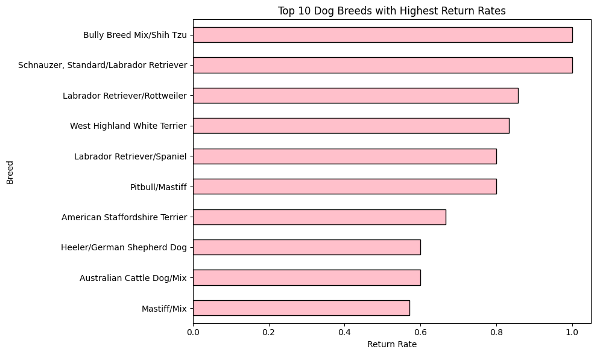

```python
import matplotlib.pyplot as plt

contingency = pd.crosstab(processed_df['breedname'], processed_df['has_been_returned'])
contingency['return_rate'] = contingency[True] / (contingency[True] + contingency[False])
contingency = contingency[(contingency[True] + contingency[False]) >= 5]
top_10_returns = contingency.sort_values(by='return_rate', ascending=False).head(10)
plt.figure(figsize=(10, 6))
top_10_returns['return_rate'].plot(kind='barh', color='pink', edgecolor='black')
plt.xlabel('Return Rate')
plt.ylabel('Breed')
plt.title('Top 10 Dog Breeds with Highest Return Rates')
plt.gca().invert_yaxis()  # So highest return rate is at top
plt.tight_layout()
plt.show()
```

The p-value given by the chi squared test is smaller than our signifance value of 0.05, thus we reject the null hypothesis and accept the alternative hypothesis. This means that the probability of seeing this result with the null hypothesis being true is extremely unlikely. Thus, we can conclude that the breed does influence the return rate of an animal.

**Second Relationship**

Null Hypothesis: The mean time spent in shelter is equal across all intake reasons.

Alternative Hypothesis: At least one intake reason group has a significantly different mean time in shelter.

```python
# since there is a lot of data on dogs in this dataset, we'll be specifically looking at the intake reasons of dogs.
# this will minimize confounding variables (whether the type of animal influences whether an animal is returned).
dogs_df = df[df['speciesname'] == 'Dog']
dogs_df
```

|  | id | intakedate | intakereason | istransfer | animalname | breedname | basecolour | speciesname | animalage | sexname | ... | movementtype | istrial | returndate | returnedreason | deceaseddate | deceasedreason | diedoffshelter | puttosleep | isdoa | numintakes |
| --- | --- | --- | --- | --- | --- | --- | --- | --- | --- | --- | --- | --- | --- | --- | --- | --- | --- | --- | --- | --- | --- |
| 1 | 15932 | 2009-12-08 00:00:00 | Moving | 0 | Gonzo | German Shepherd Dog/Mix | Tan | Dog | 9 years 1 month. | Male | ... | Adoption | 0.0 | NaT | Stray | NaT | Died in care | 0 | 0 | 0 | 1 |
| 2 | 28859 | 2012-08-10 00:00:00 | Abandoned | 0 | Maggie | Shep Mix/Siberian Husky | Various | Dog | 6 years 8 months. | Female | ... | Adoption | 0.0 | NaT | Stray | NaT | Died in care | 0 | 0 | 0 | 1 |
| 5 | 31469 | 2013-03-26 00:00:00 | Incompatible with owner lifestyle | 0 | Bonnie | Basenji/Mix | Brown and White | Dog | 5 years 11 months. | Female | ... | Adoption | 0.0 | 2017-05-08 | Incompatible with owner lifestyle | NaT | Died in care | 0 | 0 | 0 | 2 |
| 6 | 31469 | 2013-03-26 00:00:00 | Incompatible with owner lifestyle | 0 | Bonnie | Basenji/Mix | Brown and White | Dog | 5 years 11 months. | Female | ... | Adoption | 0.0 | NaT | Stray | NaT | Died in care | 0 | 0 | 0 | 2 |
| 9 | 46238 | 2016-10-09 00:00:00 | Abandoned | 0 | Tennessee | Heeler/Mix | Brown and Black | Dog | 3 years 2 months. | Male | ... | Foster | 0.0 | 2017-07-23 | Stray | NaT | Died in care | 0 | 0 | 0 | 3 |
| ... | ... | ... | ... | ... | ... | ... | ... | ... | ... | ... | ... | ... | ... | ... | ... | ... | ... | ... | ... | ... | ... |
| 10273 | 64533 | 2019-08-23 16:31:04 | Stray | 0 | Luna | Labrador Retriever | Tan and White | Dog | 10 years 3 months. | Female | ... | Reclaimed | 0.0 | NaT | Stray | NaT | Court Order/ Legal | 0 | 0 | 0 | 1 |
| 10279 | 64553 | 2019-08-26 08:31:48 | Incompatible with owner lifestyle | 0 | Leo | Bully Breed Mix | Brindle and White | Dog | 2 years 0 months. | Male | ... | Transfer | 0.0 | NaT | Stray | NaT | Court Order/ Legal | 0 | 0 | 0 | 1 |
| 10287 | 64606 | 2019-08-29 12:10:21 | Stray | 0 | Dozer | Coonhound | Red | Dog | 6 years 8 months. | Male | ... | Reclaimed | 0.0 | NaT | Stray | NaT | Court Order/ Legal | 0 | 0 | 0 | 1 |
| 10288 | 64608 | 2019-08-29 18:58:06 | Stray | 0 | Lucy Farmer | Beagle | Tricolour | Dog | 7 years 5 months. | Female | ... | Reclaimed | 0.0 | NaT | Stray | NaT | Court Order/ Legal | 0 | 0 | 0 | 1 |
| 10289 | 64609 | 2019-08-30 10:22:37 | Stray | 0 | Rocky Hartfield | Labrador Retriever | Brown | Dog | 33 years 0 months. | Male | ... | Reclaimed | 0.0 | NaT | Stray | NaT | Court Order/ Legal | 0 | 0 | 0 | 1 |

3899 rows × 21 columns

We want to create a new column called 'sheltertime' that represents the time the animal spent in the shower. This is the movementdate - intakedate.

```python
# some of the movement dates were at an earlier time than the intake dates, which wouldn't make sense. we can assume this was an error made when the information was being entered.
# we'll normalize these times
dogs_df.loc[:, 'movementdate'] = pd.to_datetime(dogs_df['movementdate'], format='%Y-%m-%d %H:%M:%S').dt.normalize()
dogs_df.loc[:, 'intakedate'] = pd.to_datetime(dogs_df['intakedate'], format='%Y-%m-%d %H:%M:%S').dt.normalize()

dogs_df.loc[:, 'days_in_shelter'] = (dogs_df['movementdate'] - dogs_df['intakedate']).dt.days.astype('int64')
dogs_df
```

|  | id | intakedate | intakereason | istransfer | animalname | breedname | basecolour | speciesname | animalage | sexname | ... | istrial | returndate | returnedreason | deceaseddate | deceasedreason | diedoffshelter | puttosleep | isdoa | numintakes | days_in_shelter |
| --- | --- | --- | --- | --- | --- | --- | --- | --- | --- | --- | --- | --- | --- | --- | --- | --- | --- | --- | --- | --- | --- |
| 1 | 15932 | 2009-12-08 | Moving | 0 | Gonzo | German Shepherd Dog/Mix | Tan | Dog | 9 years 1 month. | Male | ... | 0.0 | NaT | Stray | NaT | Died in care | 0 | 0 | 0 | 1 | 2694 |
| 2 | 28859 | 2012-08-10 | Abandoned | 0 | Maggie | Shep Mix/Siberian Husky | Various | Dog | 6 years 8 months. | Female | ... | 0.0 | NaT | Stray | NaT | Died in care | 0 | 0 | 0 | 1 | 1709 |
| 5 | 31469 | 2013-03-26 | Incompatible with owner lifestyle | 0 | Bonnie | Basenji/Mix | Brown and White | Dog | 5 years 11 months. | Female | ... | 0.0 | 2017-05-08 | Incompatible with owner lifestyle | NaT | Died in care | 0 | 0 | 0 | 2 | 4 |
| 6 | 31469 | 2013-03-26 | Incompatible with owner lifestyle | 0 | Bonnie | Basenji/Mix | Brown and White | Dog | 5 years 11 months. | Female | ... | 0.0 | NaT | Stray | NaT | Died in care | 0 | 0 | 0 | 2 | 1505 |
| 9 | 46238 | 2016-10-09 | Abandoned | 0 | Tennessee | Heeler/Mix | Brown and Black | Dog | 3 years 2 months. | Male | ... | 0.0 | 2017-07-23 | Stray | NaT | Died in care | 0 | 0 | 0 | 3 | 48 |
| ... | ... | ... | ... | ... | ... | ... | ... | ... | ... | ... | ... | ... | ... | ... | ... | ... | ... | ... | ... | ... | ... |
| 10273 | 64533 | 2019-08-23 | Stray | 0 | Luna | Labrador Retriever | Tan and White | Dog | 10 years 3 months. | Female | ... | 0.0 | NaT | Stray | NaT | Court Order/ Legal | 0 | 0 | 0 | 1 | 1 |
| 10279 | 64553 | 2019-08-26 | Incompatible with owner lifestyle | 0 | Leo | Bully Breed Mix | Brindle and White | Dog | 2 years 0 months. | Male | ... | 0.0 | NaT | Stray | NaT | Court Order/ Legal | 0 | 0 | 0 | 1 | 0 |
| 10287 | 64606 | 2019-08-29 | Stray | 0 | Dozer | Coonhound | Red | Dog | 6 years 8 months. | Male | ... | 0.0 | NaT | Stray | NaT | Court Order/ Legal | 0 | 0 | 0 | 1 | 0 |
| 10288 | 64608 | 2019-08-29 | Stray | 0 | Lucy Farmer | Beagle | Tricolour | Dog | 7 years 5 months. | Female | ... | 0.0 | NaT | Stray | NaT | Court Order/ Legal | 0 | 0 | 0 | 1 | 1 |
| 10289 | 64609 | 2019-08-30 | Stray | 0 | Rocky Hartfield | Labrador Retriever | Brown | Dog | 33 years 0 months. | Male | ... | 0.0 | NaT | Stray | NaT | Court Order/ Legal | 0 | 0 | 0 | 1 | 0 |

3899 rows × 22 columns

We'll use an ANOVA test because we want to compare the means of the shelter times of 3 or more groups. Before we proceed, we must ensure we are working with normal distributions.

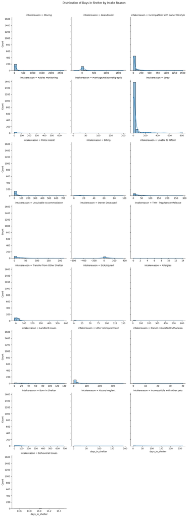

```python
import seaborn as sns
import matplotlib.pyplot as plt

# Plot histograms with KDE (Kernel Density Estimate)
g = sns.FacetGrid(dogs_df, col="intakereason", col_wrap=3, height=4, sharex=False)
g.map(sns.histplot, "days_in_shelter", kde=True, bins=20)
plt.suptitle("Distribution of Days in Shelter by Intake Reason", y=1.02)
plt.show()
```

We can observe that most of the data is skewed, so we will use the Kruskal-Wallis test, an extension of the ANOVA test that compares the medians instead of the means.

For this test, we'll use an alpha-value of 0.05

```python
from scipy.stats import kruskal

groups = []
unique_reasons = dogs_df['intakereason'].unique()

for reason in unique_reasons:
    group_data = dogs_df[dogs_df['intakereason'] == reason]['days_in_shelter'].dropna().values
    groups.append(group_data)

h_stat, p_value = kruskal(*groups)
print(f"H-statistic = {h_stat}, p-value = {p_value}")
```

```
H-statistic = 245.8431899144991, p-value = 2.8027125597278104e-40
```

We're not done yet, we will now do a post-hoc test to determine which group(s) is different. We'll do Dunn's test, which is a post-hoc test often used after the Kruskal-Wallis test, and we'll also use it with Bonferroni's Correction.

```python
!pip install scikit-posthocs
import scikit_posthocs as sp

dunn_results = sp.posthoc_dunn(
    dogs_df,
    val_col='days_in_shelter',
    group_col='intakereason',
    p_adjust='bonferroni'  # adjust for multiple comparisons
)

sig_matrix = dunn_results < 0.05

sig_pairs = []
for i in range(len(sig_matrix)):
    for j in range(i+1, len(sig_matrix)):
        if sig_matrix.iloc[i,j]:
            group1 = sig_matrix.columns[i]
            group2 = sig_matrix.columns[j]
            p_value = dunn_results.iloc[i,j]
            sig_pairs.append((group1, group2, p_value))

# Sort by most significant
sig_pairs_sorted = sorted(sig_pairs, key=lambda x: x[2])
for pair in sig_pairs_sorted:
    print(f"{pair[0]} vs {pair[1]}: p = {pair[2]}")
```

```
Incompatible with owner lifestyle vs Stray: p = 1.0558961046893137e-18
Incompatible with owner lifestyle vs Police Assist: p = 1.6165037726087948e-14
Abandoned vs Police Assist: p = 1.1902287952569855e-13
Abandoned vs Stray: p = 1.2415188958203332e-11
Moving vs Police Assist: p = 6.0212524513019004e-09
Police Assist vs Unable to Afford: p = 6.914123766902646e-07
Abandoned vs Litter relinquishment: p = 7.101471212936563e-07
Police Assist vs Unsuitable Accommodation: p = 1.5365379314565627e-06
Moving vs Stray: p = 2.6356301668454098e-06
Incompatible with owner lifestyle vs Litter relinquishment: p = 6.583734774885974e-06
Born in Shelter vs Police Assist: p = 4.588012496439033e-05
Incompatible with other pets vs Police Assist: p = 0.00044099464415841194
Abuse/ neglect vs Police Assist: p = 0.0006716277329682584
Stray vs Unable to Afford: p = 0.0008461442485991065
Marriage/Relationship split vs Police Assist: p = 0.001552774946825731
Stray vs Unsuitable Accommodation: p = 0.0019140535312164129
Landlord issues vs Police Assist: p = 0.0019188842470016859
Owner Deceased vs Police Assist: p = 0.0023279732609178027
Litter relinquishment vs Moving: p = 0.0026742476737209556
Police Assist vs Transfer from Other Shelter: p = 0.0035255395622166923
Abandoned vs Transfer from Other Shelter: p = 0.009645354055084642
Born in Shelter vs Stray: p = 0.013352471268451531
Born in Shelter vs Litter relinquishment: p = 0.021890040350999333
Litter relinquishment vs Unable to Afford: p = 0.022696168711155436
Abuse/ neglect vs Litter relinquishment: p = 0.03412470977244514
Litter relinquishment vs Unsuitable Accommodation: p = 0.036897407681607985
Abuse/ neglect vs Stray: p = 0.03772367319712416
Incompatible with other pets vs Stray: p = 0.04880801777650578
```

Printed above are the all the intake reason groups which have shelter time medians that are statistically significant from other groups' medians.

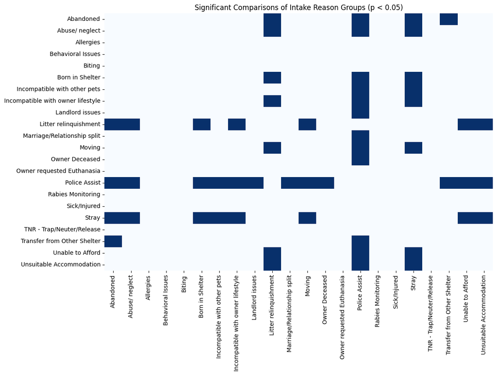

```python
plt.figure(figsize=(12,8))
sns.heatmap(dunn_results < 0.05, cmap='Blues', cbar=False)
plt.title("Significant Comparisons of Intake Reason Groups (p < 0.05)")
plt.show()
```

**Third Relationship**

Another hypothesis we can test is if age has on the reason for adoption for a pet. For example, does an older pet mean that it will be more likely to be abandonded? \ H0: The mean age of any adopted pet is the same as the mean of an abandoned pet. \ HA: The mean age of any adopted pet is different than the mean of an abandoned pet.

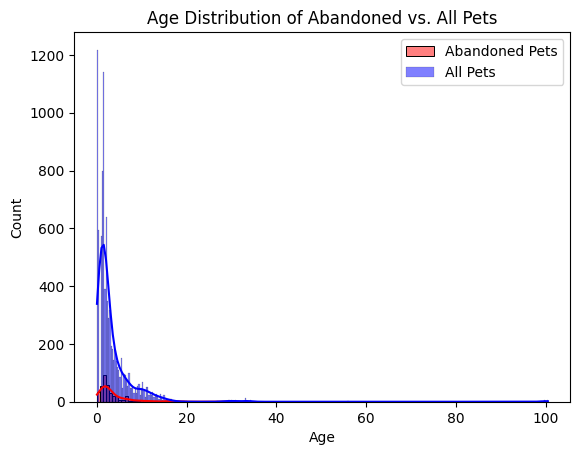

[figure not shown]

```
T-statistic: 0.3805
P-value: 0.7038
There is no significant difference between the age distributions.
```

```python
#Create a new df for our analysis
age_df = df

#create a function to make doing analysis with age a little bit easier, changes animal age entries into decimal year entries
def x(n):
    parts = n.split()

    if ("year" in parts or "years" in parts):
        years = int(parts[0])
        months = int(parts[2]) if "months." in parts or "month." in parts else 0
        return round(years + (months / 12), 2)

    elif ("week." in parts or "weeks." in parts):
        weeks = int(parts[0])
        return round(weeks / 52, 2)

    return None

# Apply function to create new 'Age' column
age_df['Age'] = age_df['animalage'].apply(x)
age_df


#Create a new df for only abandoned pets
abandoned_df = age_df[age_df['intakereason']=='Abandoned']
abandoned_df

#Now we can do staistical tests.
# Extract 'Age' values from both dataframes
ages_abandoned = abandoned_df['Age'].dropna()
ages_all = age_df['Age'].dropna()

# Plot distributions using histograms
sns.histplot(ages_abandoned, color="red", label="Abandoned Pets",kde=True)
sns.histplot(ages_all, color="blue", label="All Pets",kde=True)
plt.xlabel("Age")
plt.ylabel("Count")
plt.title("Age Distribution of Abandoned vs. All Pets")
plt.legend()
plt.show()

# Boxplot comparison
sns.boxplot(data=[ages_abandoned, ages_all], palette=["red", "blue"])
plt.xticks([0,1], ["Abandoned", "All Pets"])
plt.ylabel("Age")
plt.title("Age Comparison of Abandoned vs. All Pets")
plt.show()

# Perform an independent t-test
t_stat, p_value = stats.ttest_ind(ages_abandoned, ages_all, equal_var=False)

# Print results
print(f"T-statistic: {t_stat:.4f}")
print(f"P-value: {p_value:.4f}")

# Interpretation of results
if p_value < 0.05:
    print("The age distributions are significantly different.")
else:
    print("There is no significant difference between the age distributions.")
```

Since we have a p-value of .7038 which is above the alpha value of .05, we fail to reject the null hypothesis. Hence, the the mean age of any adopted pet is the same as the mean of an abandoned pet.

# **Primary Analysis**

We decided to utilize random to classify whether an animal would be returned to the shelter. This was mainly because our dependent variable, or ultimate outcome, is a binary yes/no answer, which can fits the output from a random forest. We also liked that random forest models are able to gain higher accuracy scores, due to the combination of several models that reduces overall variance. Random forest is also resistant to overfitting as the different base models are trained on different subsections of the data.

In order to utilize the random forest classification, we had to transform our categorical variables, color and breed, into a vector using one-hot encoding.

# **Model Creation**

We used the sklearn library to create a random forest classifier for predicting whether an adopted animal will be returned or not. After adding all appropriate import statements, we preprocessed the data to be a better input for the model.

First, we created a new column "returned" to indicate whether an animal was returned to the shelter, based on whether a date is present in the returndate column.

We then split the variable into training features (age, color, and breed) and the target variable (returned).

We use the train_test_split method to randomly split the data.

Next, we use a transformer pipeline with a oneHotEncoder to change the categorical variables breed and color into numerical data for the model.

```python
from sklearn.model_selection import train_test_split
from sklearn.linear_model import LogisticRegression
from sklearn.preprocessing import OneHotEncoder
from sklearn.compose import ColumnTransformer
from sklearn.pipeline import Pipeline
from sklearn.neighbors import KNeighborsClassifier
from sklearn.tree import DecisionTreeClassifier
from sklearn.ensemble import RandomForestClassifier

# Step 1: Specify what variables are to be used in estimation
age_df['returned'] = age_df['returndate'].notna()
null = age_df.isna().sum()
print(null)
model_df = age_df[['breedname', 'Age', 'basecolour', 'returned']].copy()
temp = model_df['Age'].mean()
model_df['Age'] = model_df['Age'].fillna(temp)

# Step 2: Split into features and target variables
x = model_df[['breedname', 'Age', 'basecolour']]
y = model_df['returned'].astype(int)

# Step 3: Split data into seperate sets
X_train, X_test, y_train, y_test = train_test_split(x, y, test_size=0.2, random_state=42)

# Step 4: Split the features
categorical_features = ['breedname', 'basecolour']
numeric_features = ['Age']

# Step 5: Process features
preprocessor = ColumnTransformer(
    transformers=[
        ('encoding', OneHotEncoder(handle_unknown='ignore'), categorical_features)
    ],
    remainder='passthrough'
)

# Step 6: Create pipeline
model_pipeline = Pipeline([
    ('preprocessing', preprocessor),
    # ('classifier', LogisticRegression(max_iter=100))
    # ('classifier', KNeighborsClassifier(n_neighbors=5))
    # ('classifier', DecisionTreeClassifier(max_depth=5, random_state=42))
    ('classifier', RandomForestClassifier(n_estimators=100, random_state=42))
])

# # Step 7: Fit the model
model_pipeline.fit(X_train, y_train)
```

```
id                   0
intakedate           0
intakereason         0
istransfer           0
animalname           0
breedname            0
basecolour           0
speciesname          0
animalage            0
sexname              0
movementdate         0
movementtype         0
istrial              0
returndate        6990
returnedreason       0
deceaseddate      9917
deceasedreason       0
diedoffshelter       0
puttosleep           0
isdoa                0
numintakes           0
Age               1093
returned             0
dtype: int64
```

```
Pipeline(steps=[('preprocessing',
                 ColumnTransformer(remainder='passthrough',
                                   transformers=[('encoding',
                                                  OneHotEncoder(handle_unknown='ignore'),
                                                  ['breedname',
                                                   'basecolour'])])),
                ('classifier', RandomForestClassifier(random_state=42))])
```

Next, we generated the classification report to find the accuracy, recall, and f1-score for the training and testing datasets. We see that for the training dataset, the precision, recall, and f1 score for "not returned"/0 is higher than the same metrics for the "returned"/1 cases. When we look at the support numbers, it can inferred that we see higher precision, recall, and f1 score because there is a large class imbalance, which much more data entries being "not returned".

In the testing data, the precision recall, and f1 score are much lower than the training data and there is a larger gap between the two classes ("returned" vs "non returned").

```python
from sklearn.metrics import accuracy_score, classification_report

y_pred = model_pipeline.predict(X_train)

accuracy = accuracy_score(y_train, y_pred)
print(f"Training Accuracy: {accuracy:.2f}")

print("\nTraining Classification Report:")
print(classification_report(y_train, y_pred))

y_pred = model_pipeline.predict(X_test)

accuracy = accuracy_score(y_test, y_pred)
print(f"Testing Accuracy: {accuracy:.2f}")

print("Testing Classification Report:")
print(classification_report(y_test, y_pred))
```

```
Training Accuracy: 0.78

Training Classification Report:
              precision    recall  f1-score   support

           0       0.81      0.89      0.85      5595
           1       0.70      0.54      0.61      2598

    accuracy                           0.78      8193
   macro avg       0.75      0.71      0.73      8193
weighted avg       0.77      0.78      0.77      8193

Testing Accuracy: 0.57
Testing Classification Report:
              precision    recall  f1-score   support

           0       0.67      0.71      0.69      1395
           1       0.30      0.27      0.29       654

    accuracy                           0.57      2049
   macro avg       0.49      0.49      0.49      2049
weighted avg       0.56      0.57      0.56      2049
```

# **Visualization**

We'll first plot a confusion matrix to show the comparison between the true labels and the predicted labels. 0 = not returned 1 = returned

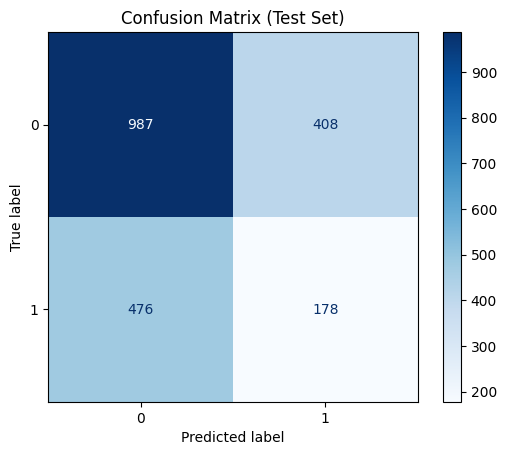

```python
import matplotlib.pyplot as plt
from sklearn.metrics import ConfusionMatrixDisplay, confusion_matrix

cm = confusion_matrix(y_test, y_pred)
disp = ConfusionMatrixDisplay(confusion_matrix=cm, display_labels=model_pipeline.classes_)
disp.plot(cmap=plt.cm.Blues)
plt.title('Confusion Matrix (Test Set)')
plt.show()
```

From this matrix we can see that there are 178 true positives, 408 false positives, 476 false negatives, and 987 true negatives. We can conclude that our model is much better at predicting non-returns (class 0) than returns (class 1). There is also a relatively high number of false negatives and false positives.

Next we'll plot a bar plot of feature importances. We limited it to top 20 most important features because the original visualization was quite overcrowded.

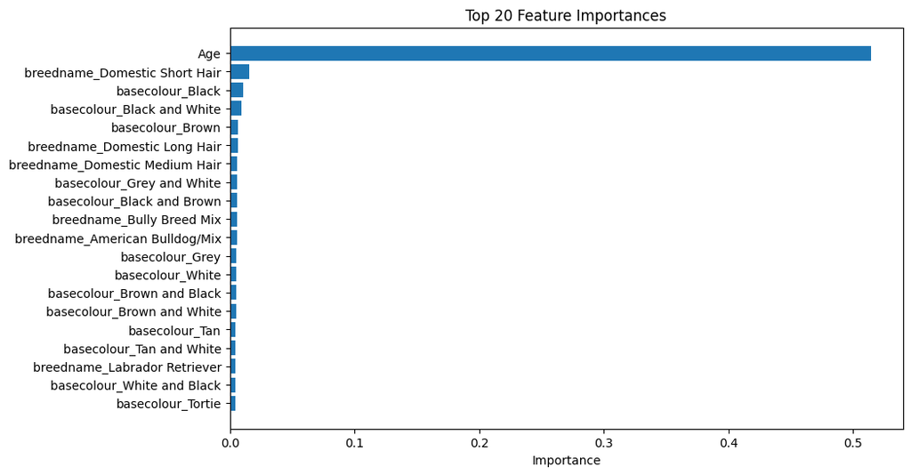

```python
import pandas as pd
import numpy as np
import matplotlib.pyplot as plt

ohe = model_pipeline.named_steps['preprocessing'].named_transformers_['encoding']
encoded_features = list(ohe.get_feature_names_out(categorical_features))
all_features = encoded_features + numeric_features

importances = model_pipeline.named_steps['classifier'].feature_importances_

feat_importance = pd.DataFrame({
    'Feature': all_features,
    'Importance': importances
}).sort_values(by='Importance', ascending=False)

plt.figure(figsize=(10, 6))
plt.barh(feat_importance['Feature'][:20][::-1], feat_importance['Importance'][:20][::-1])
plt.xlabel("Importance")
plt.title(f"Top 20 Feature Importances")
plt.show()
```

The above plot views the breed and color variables as each individual breed instead of as one field that can influence. So we have aggregated the individual breeds and colors as one variable each.

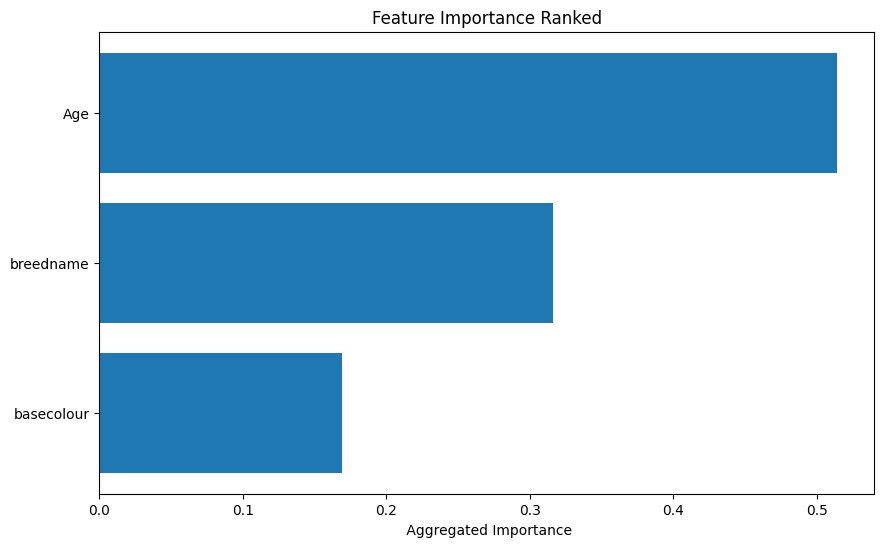

```python
from collections import defaultdict

encoded_feature_names = list(ohe.get_feature_names_out(categorical_features))
feature_names = encoded_feature_names + numeric_features
importances = model_pipeline.named_steps['classifier'].feature_importances_

feature_group_map = defaultdict(list)
for name, importance in zip(feature_names, importances):
    if name.startswith('breedname_'):
        feature_group_map['breedname'].append(importance)
    elif name.startswith('basecolour_'):
        feature_group_map['basecolour'].append(importance)
    elif name == 'Age':
        feature_group_map['Age'].append(importance)

grouped_importance = {feature: sum(importances) for feature, importances in feature_group_map.items()}

grouped_df = pd.DataFrame.from_dict(grouped_importance, orient='index', columns=['Importance'])
grouped_df = grouped_df.sort_values(by='Importance', ascending=False)


plt.figure(figsize=(10, 6))
plt.barh(grouped_df.index[::-1], grouped_df['Importance'][::-1])
plt.xlabel(" Aggregated Importance")
plt.title(f"Feature Importance Ranked")
plt.show()
```

# **Insights and Conclusions**

On the other hand, a reader informed both on machine learning and animal shelters may not learn nearly as much as the uninformed reader, but may gain some additional insights from our project. For example, even an informed reader may not know the details on how breed and color variables can impact return rate, but our visualization section helps show that.